# 14. Computer Vision

Dive-into-Deep-Learning

Author

Wu Hao

Published

2025/2/19

# Configuration

## Packages

```python
import torch
from torch import nn
from d2l import torch as d2l
import torchvision
from torch.utils import data
from torch.utils.data import DataLoader
from torchvision import transforms
import time
import numpy as np
from torch.nn import functional as F
import os
```

## GPU and Config

```python
device = 'cuda' if torch.cuda.is_available() else 'cpu'

config_aug = {
    'n_epochs': 10,     # Number of epochs.
    'batch_size': 128,
    'learning_rate': 1e-3,
}

config_ft = {
    'datafile': './data/hotdog',
    'n_epochs': 10,     # Number of epochs.
    'batch_size': 128,
    'learning_rate': 1e-3,
}
```

# Image Augmentation

Image augmentation generates similar but distinct training examples after a series of random changes to the training images, thereby expanding the size of the training set.

## Common Image Augmentation Methods

In our investigation of common image augmentation methods, we will use the following $400 \times 500$ image an example.

```python
d2l.set_figsize()
img = d2l.Image.open('./data/cat1.jpg')
d2l.plt.imshow(img)
```

[figure not shown]

We define an auxiliary function `apply`. This function runs the image augmentation method `aug` multiple times on the input image `img` and shows all the results.

```python
def apply(img, aug, num_rows=2, num_cols=4, scale=1.5):
    Y = [aug(img) for _ in range(num_rows * num_cols)]
    d2l.show_images(Y, num_rows, num_cols, scale=scale)
```

### Flipping and Cropping

Flipping the image left and right as well as up and down usually does not change the category of the object. This is one of the earliest and most widely used methods of image augmentation. Next, we use the `transforms` module to create the `RandomHorizontalFlip` instance, which flips an image left and right with a 50% chance.

```python
print('left and right')
apply(img, torchvision.transforms.RandomHorizontalFlip())
```

```
left and right
```

[figure not shown]

```python
print('up and down')
apply(img, torchvision.transforms.RandomVerticalFlip())
```

```
up and down
```

[figure not shown]

In the example image we used, the cat is in the middle of the image, but this may not be the case in general. `Pooling` can solve this problem by reducing the sensitivity of a convolutional layer to the target position. In addition, we can also randomly crop the image to make objects appear in different positions in the image at different scales, which can also reduce the sensitivity of a model to the target position.

```python
shape_aug = torchvision.transforms.RandomResizedCrop((200,200), scale=(0.1, 1), ratio=(0.5,2))
apply(img, shape_aug)
```

[figure not shown]

### Changing Colors

Another augmentation method is changing colors. We can change four aspects of the image color: brightness, contrast, saturation, and hue.

```python
apply(img, torchvision.transforms.ColorJitter(
    brightness=0.5, contrast=0, saturation=0, hue=0))
```

[figure not shown]

```python
apply(img, torchvision.transforms.ColorJitter(
    brightness=0, contrast=0, saturation=0, hue=0.5))
```

[figure not shown]

```python
color_aug = torchvision.transforms.ColorJitter(
    brightness=0.5, contrast=0.5, saturation=0.5, hue=0.5)
apply(img, color_aug)
```

[figure not shown]

### Combining Multiple Image Augmentation Methods

```python
augs = torchvision.transforms.Compose([
    torchvision.transforms.RandomHorizontalFlip(), color_aug, shape_aug])
apply(img, augs)
```

[figure not shown]

## Training with Image Augmentation

Here we use the CIFAR-10 dataset instead of the Fashion-MNIST dataset that we used before. This is because the position and size of the objects in the Fashion-MNIST dataset have been normalized, while the color and size of the objects in the CIFAR-10 dataset have more significant differences.

```python
all_images = torchvision.datasets.CIFAR10(train=True, root="./data",
                                          download=True)
d2l.show_images([all_images[i][0] for i in range(32)], 4, 8, scale=0.8)
```

```
Files already downloaded and verified
```

```
array([<Axes: >, <Axes: >, <Axes: >, <Axes: >, <Axes: >, <Axes: >,
       <Axes: >, <Axes: >, <Axes: >, <Axes: >, <Axes: >, <Axes: >,
       <Axes: >, <Axes: >, <Axes: >, <Axes: >, <Axes: >, <Axes: >,
       <Axes: >, <Axes: >, <Axes: >, <Axes: >, <Axes: >, <Axes: >,
       <Axes: >, <Axes: >, <Axes: >, <Axes: >, <Axes: >, <Axes: >,
       <Axes: >, <Axes: >], dtype=object)
```

[figure not shown]

We only apply image augmentation to training examples.

```python
train_augs = torchvision.transforms.Compose([
     torchvision.transforms.RandomHorizontalFlip(),
     torchvision.transforms.ToTensor()])
```

### Preprocess Data

```python
def ImgDataloader(is_train, config, trans = None):
    if not trans:
        trans = torchvision.transforms.Compose([
        torchvision.transforms.ToTensor()
        ])

    dataset = torchvision.datasets.CIFAR10(root="./data", train=is_train,
                                           transform=trans, download=True)
    dataloader = torch.utils.data.DataLoader(dataset, batch_size=config['batch_size'],
                    shuffle=is_train)

    data_len = len(dataset)
    return dataloader, data_len
```

### Define Trainer

```python
def trainer(train_iter, test_iter, train_len, test_len, model, config, device):

    #optimization algorithm.
    optimizer = torch.optim.Adam(model.parameters(), lr=config['learning_rate'])
    criterion = nn.CrossEntropyLoss()
    n_epochs= config['n_epochs']
    model.to(device)

    for epoch in range(n_epochs):
        model.train()
        epoch_start_time = time.time()
        loss_record = []
        train_acc = 0.0
        #x: features, y: labels
        for X, y in train_iter:
            optimizer.zero_grad()               # Set gradient to zero.
            X, y = X.to(device), y.to(device)
            train_pred = model(X)
            batch_loss = criterion(train_pred, y)
            batch_loss.backward()               # Compute gradient(back propagation).
            optimizer.step()                    # Update parameters.
            train_acc += np.sum(np.argmax(train_pred.detach().cpu().numpy(), axis=1) == y.cpu().numpy())
            loss_record.append(batch_loss.detach().item()) #detach(): separation gradient

        mean_train_loss = sum(loss_record)/len(loss_record)
        train_acc = train_acc / train_len

        model.eval() # Set our model to evaluation mode.
        loss_record = []
        test_acc = 0.0
        with torch.no_grad():
            for x, y in test_iter:
                x, y = x.to(device), y.to(device)
                test_pred = model(x)
                batch_loss = criterion(test_pred, y)
                test_acc += np.sum(np.argmax(test_pred.detach().cpu().numpy(), axis=1) == y.cpu().numpy())
                loss_record.append(batch_loss.item())

            mean_test_loss = sum(loss_record)/len(loss_record)
            test_acc = test_acc / test_len
            print('[%03d/%03d] %2.2f sec(s) Train Acc: %3.6f Loss: %3.6f | Test Acc: %3.6f loss: %3.6f' % \
              (epoch + 1, n_epochs, time.time() - epoch_start_time, \
               train_acc, mean_train_loss, test_acc, mean_test_loss))
```

### Start Training

```python
train_iter, train_len = ImgDataloader(True, config_aug, trans = train_augs)
test_iter, test_len = ImgDataloader(False, config_aug)
model = d2l.resnet18(10, 3)
trainer(train_iter, test_iter, train_len, test_len, model, config_aug, device)

print('Data without Augmentation')
model = d2l.resnet18(10, 3)
train_iter_init,train_len_init= ImgDataloader(True, config_aug)
trainer(train_iter_init, test_iter, train_len_init, test_len, model, config_aug, device)
```

```
Files already downloaded and verified
Files already downloaded and verified
[001/010] 12.89 sec(s) Train Acc: 0.483100 Loss: 1.411254 | Test Acc: 0.580300 loss: 1.240776
[002/010] 12.31 sec(s) Train Acc: 0.688760 Loss: 0.875315 | Test Acc: 0.633900 loss: 1.080639
[003/010] 12.27 sec(s) Train Acc: 0.774420 Loss: 0.643976 | Test Acc: 0.729700 loss: 0.814754
[004/010] 12.25 sec(s) Train Acc: 0.821860 Loss: 0.512072 | Test Acc: 0.811300 loss: 0.548675
[005/010] 12.28 sec(s) Train Acc: 0.856680 Loss: 0.414981 | Test Acc: 0.813500 loss: 0.561638
[006/010] 12.34 sec(s) Train Acc: 0.879140 Loss: 0.348908 | Test Acc: 0.821800 loss: 0.561736
[007/010] 12.29 sec(s) Train Acc: 0.897120 Loss: 0.296674 | Test Acc: 0.841400 loss: 0.475384
[008/010] 12.61 sec(s) Train Acc: 0.914000 Loss: 0.245367 | Test Acc: 0.849300 loss: 0.475639
[009/010] 12.30 sec(s) Train Acc: 0.927680 Loss: 0.209128 | Test Acc: 0.846500 loss: 0.493344
[010/010] 12.56 sec(s) Train Acc: 0.941700 Loss: 0.170678 | Test Acc: 0.852500 loss: 0.506932
Data without Augmentation
Files already downloaded and verified
[001/010] 11.65 sec(s) Train Acc: 0.490820 Loss: 1.385628 | Test Acc: 0.582900 loss: 1.171052
[002/010] 11.67 sec(s) Train Acc: 0.703400 Loss: 0.835767 | Test Acc: 0.701000 loss: 0.833032
[003/010] 11.69 sec(s) Train Acc: 0.790540 Loss: 0.598081 | Test Acc: 0.732400 loss: 0.819206
[004/010] 11.71 sec(s) Train Acc: 0.844720 Loss: 0.448940 | Test Acc: 0.783900 loss: 0.628617
[005/010] 11.79 sec(s) Train Acc: 0.883740 Loss: 0.334980 | Test Acc: 0.812700 loss: 0.572326
[006/010] 11.92 sec(s) Train Acc: 0.916240 Loss: 0.240479 | Test Acc: 0.819900 loss: 0.572140
[007/010] 11.75 sec(s) Train Acc: 0.939480 Loss: 0.171524 | Test Acc: 0.830700 loss: 0.575405
[008/010] 11.76 sec(s) Train Acc: 0.956500 Loss: 0.122424 | Test Acc: 0.810400 loss: 0.709209
[009/010] 11.65 sec(s) Train Acc: 0.970200 Loss: 0.087108 | Test Acc: 0.828200 loss: 0.720311
[010/010] 11.72 sec(s) Train Acc: 0.974640 Loss: 0.073129 | Test Acc: 0.828600 loss: 0.699218
```

### Discussion

The results show that although the data augmentation dataset does not perform as well as the original dataset on the training set, it outperforms the latter on the test dataset, and thus the data augmentation has a lower degree of overfitting, which significantly improves the generalization ability of the model.

# Fine-Tuning

Suppose that we want to recognize different types of chairs from images, and then recommend purchase links to users. One possible method is to first identify 100 common chairs, take 1000 images of different angles for each chair, and then we want to train a classification model on the collected image dataset. Although this chair dataset may be larger than the Fashion-MNIST dataset, the number of examples is still less than one-tenth of that in ImageNet. This may lead to overfitting of complicated models that are suitable for ImageNet on this chair dataset. Besides, due to the limited amount of training examples, the accuracy of the trained model may not meet practical requirements.

In order to address the above problems, *transfer learning* is proposed. Transfer learning transfers the knowledge learned from the source dataset to the target dataset to improve the performance of a model on a new task.

## Steps

In this section, we will introduce a common technique in transfer learning: **fine-tuning**, which consists of the following four steps:

1. Pretrain a neural network model, i.e., the source model, on a source dataset (e.g., the ImageNet dataset).
2. Create a new neural network model, i.e., the target model. This copies all model designs and their parameters on the source model except the output layer. We assume that these model parameters contain the knowledge learned from the source dataset and this knowledge will also be applicable to the target dataset. We also assume that the output layer of the source model is closely related to the labels of the source dataset; thus it is not used in the target model.
3. Add an output layer to the target model, whose number of outputs is the number of categories in the target dataset. Then randomly initialize the model parameters of this layer.
4. Train the target model on the target dataset, such as a chair dataset. The output layer will be trained from scratch, while the parameters of all the other layers are fine-tuned based on the parameters of the source model.

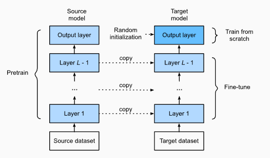

Fine tuning

When target datasets are much smaller than source datasets, fine-tuning helps to improve models’ generalization ability.

## Hot Dog Recognition

### Reading the Dataset

This dataset consists of 1400 positive-class images containing hot dogs, and as many negative-class images containing other foods. 1000 images of both classes are used for training and the rest are for testing.

```python
# Download data
d2l.DATA_HUB['hotdog'] = (d2l.DATA_URL + 'hotdog.zip',
                         'fba480ffa8aa7e0febbb511d181409f899b9baa5')
```

```python
data_dir = config_ft['datafile']
train_imgs = torchvision.datasets.ImageFolder(os.path.join(data_dir, 'train'))
test_imgs = torchvision.datasets.ImageFolder(os.path.join(data_dir, 'test'))

hotdogs = [train_imgs[i][0] for i in range(8)]
not_hotdogs = [train_imgs[-i - 1][0] for i in range(8)]
d2l.show_images(hotdogs + not_hotdogs, 2, 8, scale=1.4)
```

```
array([<Axes: >, <Axes: >, <Axes: >, <Axes: >, <Axes: >, <Axes: >,
       <Axes: >, <Axes: >, <Axes: >, <Axes: >, <Axes: >, <Axes: >,
       <Axes: >, <Axes: >, <Axes: >, <Axes: >], dtype=object)
```

[figure not shown]

During training, we first crop a random area of random size and random aspect ratio from the image, and then scale this area to a $224 \times 224$ input image.

```python
# Specify the means and standard deviations of the three RGB channels to
# standardize each channel
normalize = torchvision.transforms.Normalize(
    [0.485, 0.456, 0.406], [0.229, 0.224, 0.225])

train_augs = torchvision.transforms.Compose([
    torchvision.transforms.RandomResizedCrop(224),
    torchvision.transforms.RandomHorizontalFlip(),
    torchvision.transforms.ToTensor(),
    normalize])

test_augs = torchvision.transforms.Compose([
    torchvision.transforms.Resize([256, 256]),
    torchvision.transforms.CenterCrop(224),
    torchvision.transforms.ToTensor(),
    normalize])

train_data = torchvision.datasets.ImageFolder(os.path.join(data_dir, 'train'), transform=train_augs)
test_data = torchvision.datasets.ImageFolder(os.path.join(data_dir, 'test'), transform=test_augs)

train_len = len(train_data)
test_len = len(test_data)

train_iter = torch.utils.data.DataLoader(train_data, batch_size=config_ft['batch_size'], shuffle=True)
test_iter = torch.utils.data.DataLoader(test_data, batch_size=config_ft['batch_size'])
```

### Defining and Initializing the Model

We use ResNet-18, which was pretrained on the ImageNet dataset, as the source model.

```python
pretrained_net = torchvision.models.resnet18(pretrained=True)
```

The pretrained source model instance contains a number of feature layers and an output layer fc. The main purpose of this division is to facilitate the fine-tuning of model parameters of all layers but the output layer. The member variable fc of source model is given below.

```python
pretrained_net.fc
```

```
Linear(in_features=512, out_features=1000, bias=True)
```

In the code below, the model parameters before the output layer of the target model instance `finetune_net` are initialized to model parameters of the corresponding layers from the source model.

```python
finetune_net = torchvision.models.resnet18(pretrained=True)
finetune_net.fc = nn.Linear(finetune_net.fc.in_features, 2)
nn.init.xavier_uniform_(finetune_net.fc.weight)
```

```
Parameter containing:
tensor([[ 0.0723, -0.0656,  0.0025,  ..., -0.0281,  0.0350, -0.0441],
        [ 0.0713, -0.0116,  0.0271,  ...,  0.0175,  0.0681,  0.0261]],
       requires_grad=True)
```

### Fine-Tuning the Model

First, we define a training function `train_fine_tuning` that uses fine-tuning so it can be called multiple times.

```python
def train_fine_tuning(model, train_iter, test_iter, train_len, test_len, config, device, param_group=True):
    if param_group:
        params_1x = [param for name, param in model.named_parameters()
             if name not in ["fc.weight", "fc.bias"]]
        optimizer = torch.optim.Adam([{'params': params_1x},
                                   {'params': model.fc.parameters(),
                                    'lr': config['learning_rate'] * 10}],
                                lr=config['learning_rate'], weight_decay=0.001)
    else:
        optimizer = torch.optim.Adam(model.parameters(), lr=config['learning_rate'], weight_decay=0.001)

    criterion = nn.CrossEntropyLoss()
    n_epochs= config['n_epochs']
    model.to(device)

    for epoch in range(n_epochs):
        model.train()
        epoch_start_time = time.time()
        loss_record = []
        train_acc = 0.0
        #x: features, y: labels
        for X, y in train_iter:
            optimizer.zero_grad()
            X, y = X.to(device), y.to(device)
            train_pred = model(X)
            batch_loss = criterion(train_pred, y)
            batch_loss.backward()               # Compute gradient(back propagation).
            optimizer.step()       # Update parameters.
            train_acc += np.sum(np.argmax(train_pred.detach().cpu().numpy(), axis=1) == y.cpu().numpy())
            loss_record.append(batch_loss.detach().item()) #detach(): separation gradient

        mean_train_loss = sum(loss_record)/len(loss_record)
        train_acc = train_acc / train_len

        model.eval() # Set our model to evaluation mode.
        loss_record = []
        test_acc = 0.0
        with torch.no_grad():
            for x, y in test_iter:
                x, y = x.to(device), y.to(device)
                test_pred = model(x)
                batch_loss = criterion(test_pred, y)
                test_acc += np.sum(np.argmax(test_pred.detach().cpu().numpy(), axis=1) == y.cpu().numpy())
                loss_record.append(batch_loss.item())

            mean_test_loss = sum(loss_record)/len(loss_record)
            test_acc = test_acc / test_len
            print('[%03d/%03d] %2.2f sec(s) Train Acc: %3.6f Loss: %3.6f | Test Acc: %3.6f loss: %3.6f' % \
              (epoch + 1, n_epochs, time.time() - epoch_start_time, \
               train_acc, mean_train_loss, test_acc, mean_test_loss))

train_fine_tuning(finetune_net,train_iter, test_iter, train_len, test_len, config_ft, device)
```

```
[001/010] 8.35 sec(s) Train Acc: 0.787000 Loss: 0.836780 | Test Acc: 0.638750 loss: 3.427055
[002/010] 7.80 sec(s) Train Acc: 0.875500 Loss: 0.307527 | Test Acc: 0.886250 loss: 0.317086
[003/010] 7.78 sec(s) Train Acc: 0.897500 Loss: 0.242942 | Test Acc: 0.896250 loss: 0.418662
[004/010] 7.79 sec(s) Train Acc: 0.910500 Loss: 0.248453 | Test Acc: 0.901250 loss: 0.258428
[005/010] 7.81 sec(s) Train Acc: 0.919000 Loss: 0.198572 | Test Acc: 0.908750 loss: 0.210241
[006/010] 7.78 sec(s) Train Acc: 0.926500 Loss: 0.190641 | Test Acc: 0.890000 loss: 0.278360
[007/010] 7.80 sec(s) Train Acc: 0.930000 Loss: 0.182040 | Test Acc: 0.876250 loss: 0.496760
[008/010] 7.81 sec(s) Train Acc: 0.927000 Loss: 0.185687 | Test Acc: 0.895000 loss: 0.259623
[009/010] 7.83 sec(s) Train Acc: 0.936500 Loss: 0.164057 | Test Acc: 0.886250 loss: 0.281719
[010/010] 7.81 sec(s) Train Acc: 0.941000 Loss: 0.151955 | Test Acc: 0.913750 loss: 0.308323
```

For comparison, we define an identical model, but initialize all of its model parameters to random values.

```python
scratch_net = torchvision.models.resnet18()
scratch_net.fc = nn.Linear(scratch_net.fc.in_features, 2)
train_fine_tuning(scratch_net, train_iter, test_iter, train_len, test_len, config_ft, device)
```

```
[001/010] 7.96 sec(s) Train Acc: 0.705000 Loss: 0.882830 | Test Acc: 0.801250 loss: 1.972020
[002/010] 7.72 sec(s) Train Acc: 0.830000 Loss: 0.390918 | Test Acc: 0.823750 loss: 0.422877
[003/010] 7.78 sec(s) Train Acc: 0.829000 Loss: 0.384542 | Test Acc: 0.861250 loss: 0.339942
[004/010] 7.79 sec(s) Train Acc: 0.853000 Loss: 0.367619 | Test Acc: 0.853750 loss: 0.361672
[005/010] 7.79 sec(s) Train Acc: 0.837500 Loss: 0.367087 | Test Acc: 0.861250 loss: 0.359227
[006/010] 7.78 sec(s) Train Acc: 0.847000 Loss: 0.361683 | Test Acc: 0.827500 loss: 0.456629
[007/010] 7.78 sec(s) Train Acc: 0.843000 Loss: 0.363237 | Test Acc: 0.833750 loss: 0.400821
[008/010] 7.82 sec(s) Train Acc: 0.846500 Loss: 0.361685 | Test Acc: 0.856250 loss: 0.345626
[009/010] 7.82 sec(s) Train Acc: 0.856000 Loss: 0.338644 | Test Acc: 0.851250 loss: 0.369675
[010/010] 7.78 sec(s) Train Acc: 0.858500 Loss: 0.350421 | Test Acc: 0.861250 loss: 0.324301
```

Back to top